# Answers to Selected Homework Exercises

## 2.5

1. 0.18

```r
#b
.18*.8+.82*.1
```

```
[1] 0.226
```

```r
#c
(.18*.8)/(.18*.8+.82*.1)
```

```
[1] 0.6371681
```

4. Based on the tree being a maple, the probability of the tree being infected increased significantly, from 0.18 to 0.64.

## 2.10

```r
#a
.085*.1+.915*.105
```

```
[1] 0.104575
```

```r
#b
(.085*.1)/(.085*.1+.915*.105)
```

```
[1] 0.08128138
```

```r
#c
(.9*.085)/(.9*.085+.915*.895)
```

```
[1] 0.08543429
```

## 2.17

```r
trees <- data.frame(health=c("infected", "uninfected"))
prior <- c(.18,.82)
data <- c("maple", "other")

set.seed(84735)

trees_sim <- sample_n(trees, size=10000, weight=prior, replace=TRUE) %>%
  mutate(data_model = case_when(health=="infected" ~ .8,
                                health=="uninfected" ~ .1)) %>%
  group_by(1:n()) %>%
  mutate(species=sample(data, size=1, prob=c(data_model, 1-data_model)))

trees_sim %>% tabyl(species,health) %>%
  adorn_totals(c("col","row"))
```

```
 species infected uninfected Total
   maple     1482        860  2342
   other      363       7295  7658
   Total     1845       8155 10000
```

The approximate probability that a randomly selected maple tree has mold is:

```r
1482/2342
```

```
[1] 0.6327925
```

## 2.3

1. No, there is no fixed number of binary trials.
2. If we assume that the tulips bloom or fail independently, then yes, $Y\sim Binom(27,.9)$. But there is probably dependence that would lead this to not being binomial.
3. No, this is counting the number of trials until a success.
4. No, this is a continuous variable.
5. No, this is a continuous variable.
6. Yes, $Y\sim Binom(60,.8)$

## HW 2a Problem 1

$\theta$ must be between -0.3 and 0.15 in order for the f(x) values to all be between 0 and 1.

## 2.13

```r
#b
.1*dbinom(47,80,.4)/(.1*dbinom(47,80,.4)+.2*dbinom(47,80,.5)+.44*dbinom(47,80,.6)+.26*dbinom(47,80,.7)) #f(pi=.4|y=47)
```

```
[1] 0.0006491288
```

```r
.2*dbinom(47,80,.5)/(.1*dbinom(47,80,.4)+.2*dbinom(47,80,.5)+.44*dbinom(47,80,.6)+.26*dbinom(47,80,.7)) #f(pi=.5|y=47)
```

```
[1] 0.1135404
```

```r
.44*dbinom(47,80,.6)/(.1*dbinom(47,80,.4)+.2*dbinom(47,80,.5)+.44*dbinom(47,80,.6)+.26*dbinom(47,80,.7)) #f(pi=.6|y=47)
```

```
[1] 0.8337986
```

```r
.26*dbinom(47,80,.7)/(.1*dbinom(47,80,.4)+.2*dbinom(47,80,.5)+.44*dbinom(47,80,.6)+.26*dbinom(47,80,.7)) #f(pi=.7|y=47)
```

```
[1] 0.05201189
```

3. The data would have more influence compared to the prior, so the posterior probability would even more heavily center at $\pi=.6$.

## 2.18

```r
# Define possible values of pi
lactose <- data.frame(pi = c(0.4, 0.5, 0.6, 0.7))

# Define the prior model
prior <- c(0.1, 0.2, 0.44, 0.26)

# Simulate 10000 values of pi from the prior
set.seed(84735)
lactose_sim <- sample_n(lactose, size = 10000, weight = prior, replace = TRUE)

# Simulate 10000 samples
lactose_sim <- lactose_sim %>%
  mutate(y = rbinom(10000, size = 80, prob = pi))

# Focus on simulations with y = 47
filtered <- lactose_sim %>%
  filter(y == 47)

# Summarize the posterior approximation
filtered %>%
  tabyl(pi) %>%
  adorn_totals("row")
```

```
    pi   n    percent
   0.5  50 0.10683761
   0.6 399 0.85256410
   0.7  19 0.04059829
 Total 468 1.00000000
```

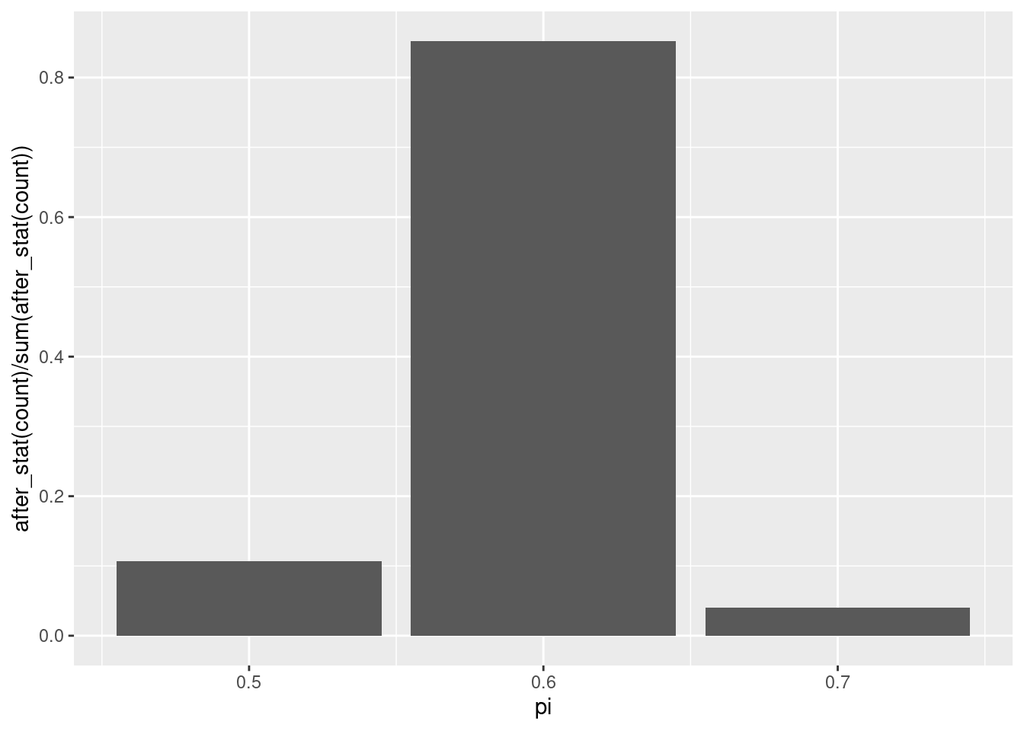

```r
# Plot the posterior approximation
ggplot(filtered, aes(x = pi, y=after_stat(count)/sum(after_stat(count)))) +
  geom_bar()
```

## 3.3

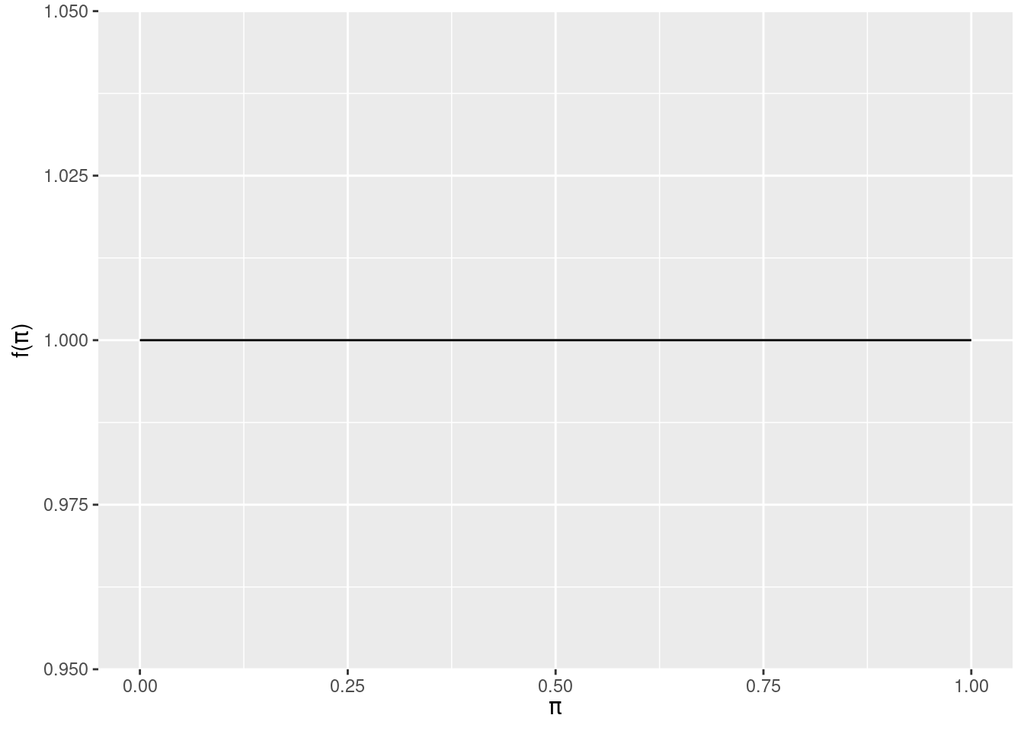

```r
#a
plot_beta(1,1)
```

```r
summarize_beta(1,1)
```

```
  mean mode        var        sd
1  0.5  NaN 0.08333333 0.2886751
```

2. The mean is 0.5. This aligns with having no clue in that if all numbers between 0 and 1 are equally likely, it makes sense that the average would be 0.5
3. $\sqrt{1/12}$

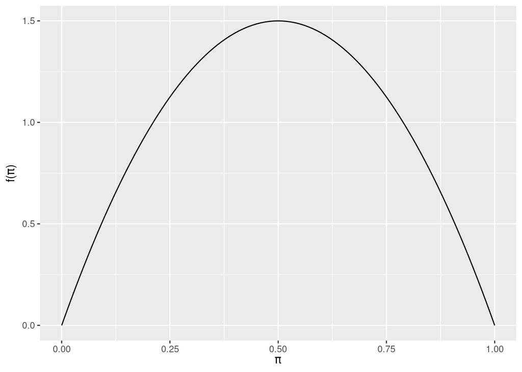

```r
#d
plot_beta(2,2)
```

```r
summarize_beta(2,2)
```

```
  mean mode  var        sd
1  0.5  0.5 0.05 0.2236068
```

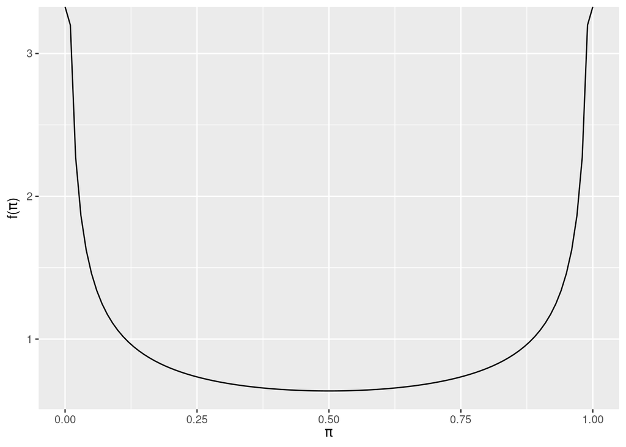

```r
#e
plot_beta(.5,.5)
```

```r
summarize_beta(.5,.5)
```

```
  mean    mode   var        sd
1  0.5 0 and 1 0.125 0.3535534
```

## 3.9

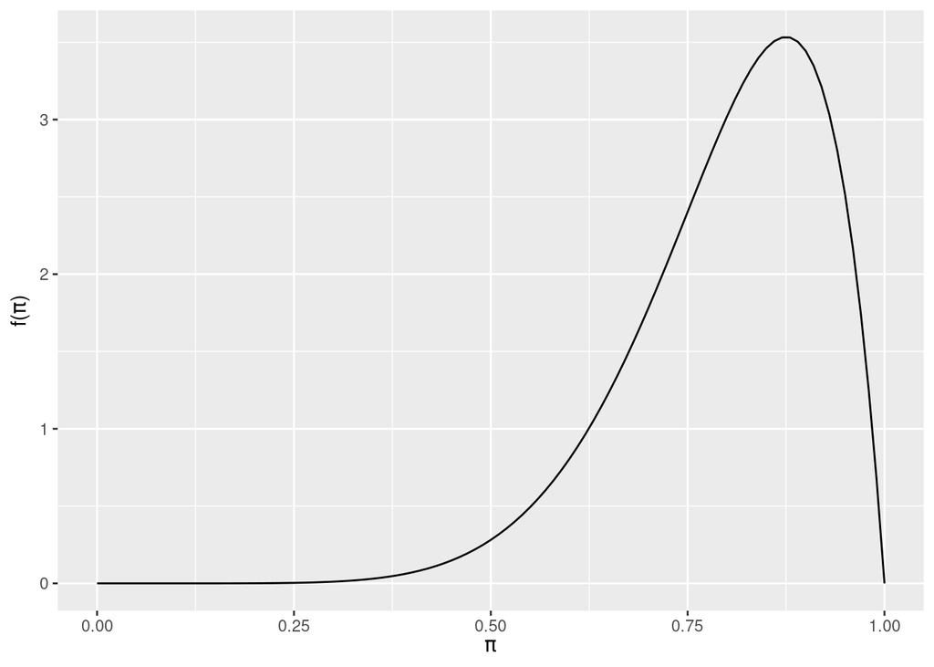

```r
#a,b
plot_beta(8,2)
```

```r
summarize_beta(8,2)
```

```
  mean  mode        var        sd
1  0.8 0.875 0.01454545 0.1206045
```

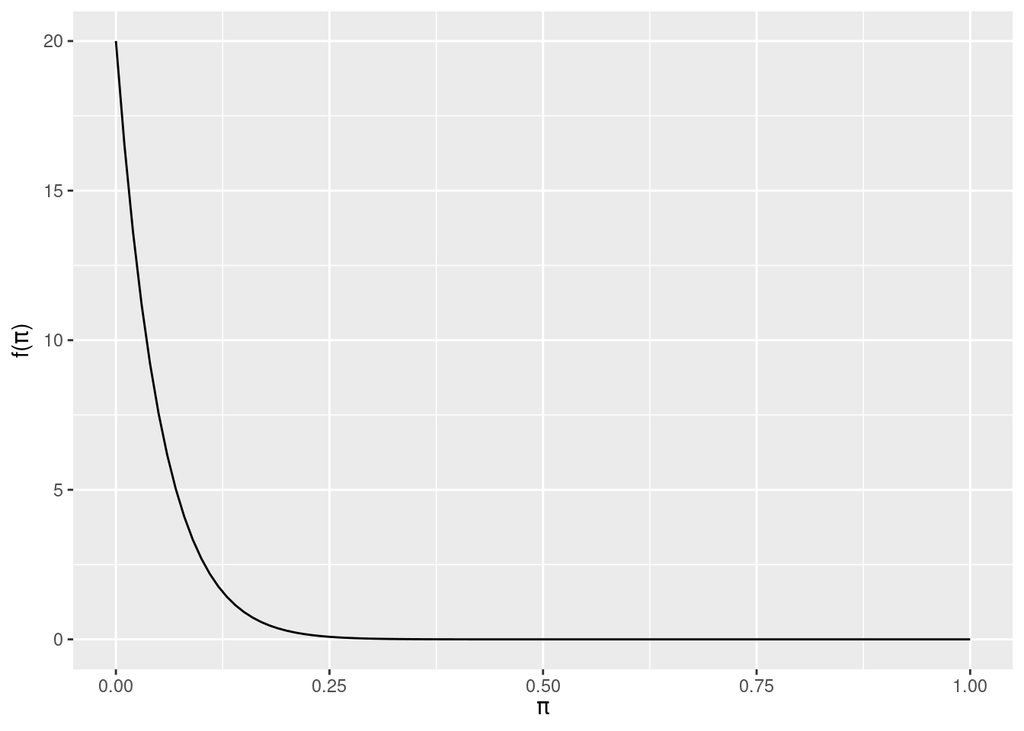

```r
plot_beta(1,20)
```

```r
summarize_beta(1,20)
```

```
        mean mode         var         sd
1 0.04761905    0 0.002061431 0.04540298
```

3. The salesperson from North Dakota thinks that most people say pop, and gives very little chance that the majority say something else. The salesperson from Louisiana thinks that very few people say pop, with virtually no chance that more than a quarter of Americans prefer that (correct) designation.

## 3.10

1. ND: Beta(20,40). LA: Beta(13,58)

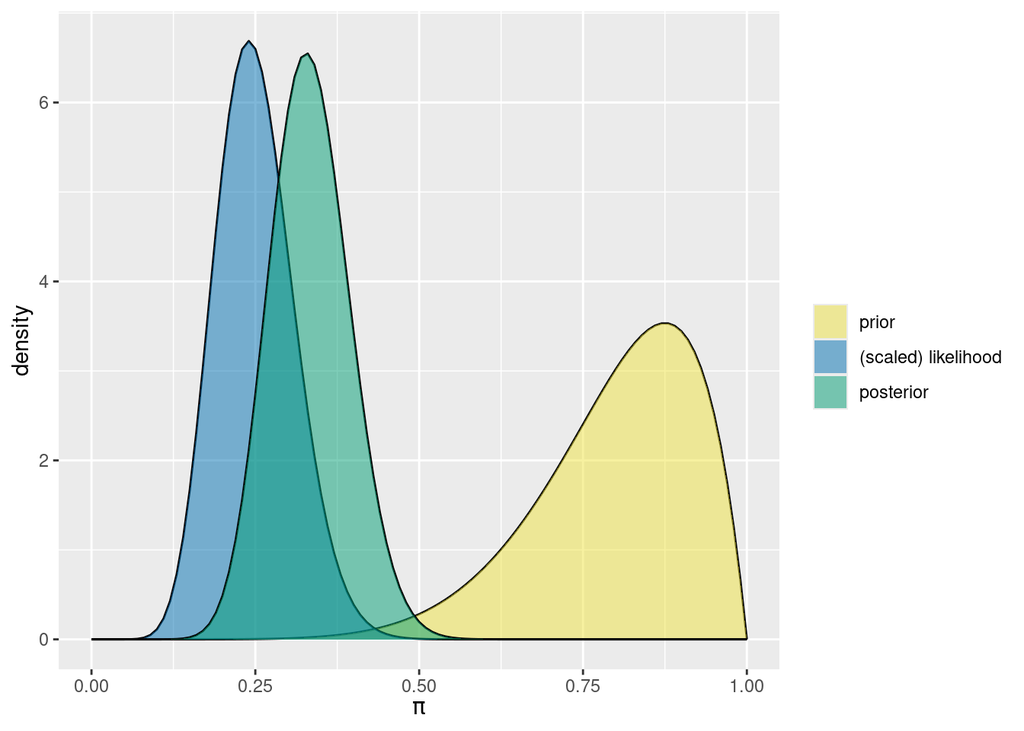

```r
#b
plot_beta_binomial(8,2,12,50) #ND
```

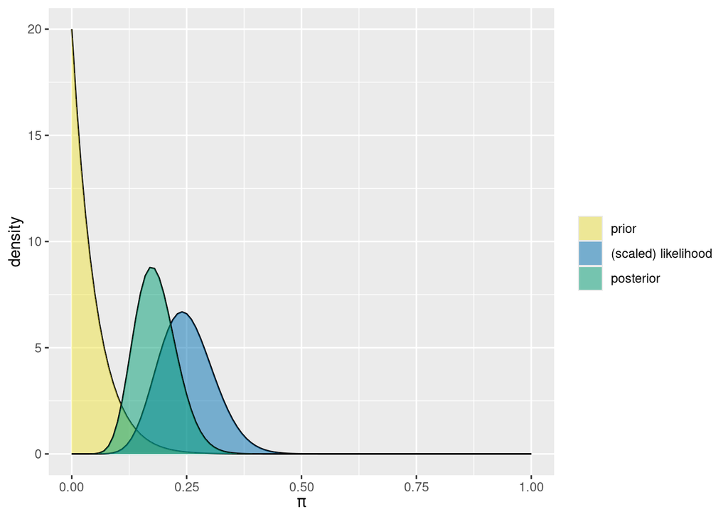

```r
plot_beta_binomial(1,20,12,50) #LA
```

3. The salespeople still have fairly different understandings of pi, although less different than their prior beliefs. The interval from 0.2 to 0.3 has reasonable probabilily for both salespeople, where there was essentially no overlap before.

## 3.14

```r
summarize_beta_binomial(2,3,9,30)
```

```
      model alpha beta      mean      mode         var         sd
1     prior     2    3 0.4000000 0.3333333 0.040000000 0.20000000
2 posterior    11   24 0.3142857 0.3030303 0.005986395 0.07737179
```

## 3.18

```r
#a
summarize_beta_binomial(3,3,30,40)
```

```
      model alpha beta      mean      mode         var        sd
1     prior     3    3 0.5000000 0.5000000 0.035714286 0.1889822
2 posterior    33   13 0.7173913 0.7272727 0.004313639 0.0656783
```

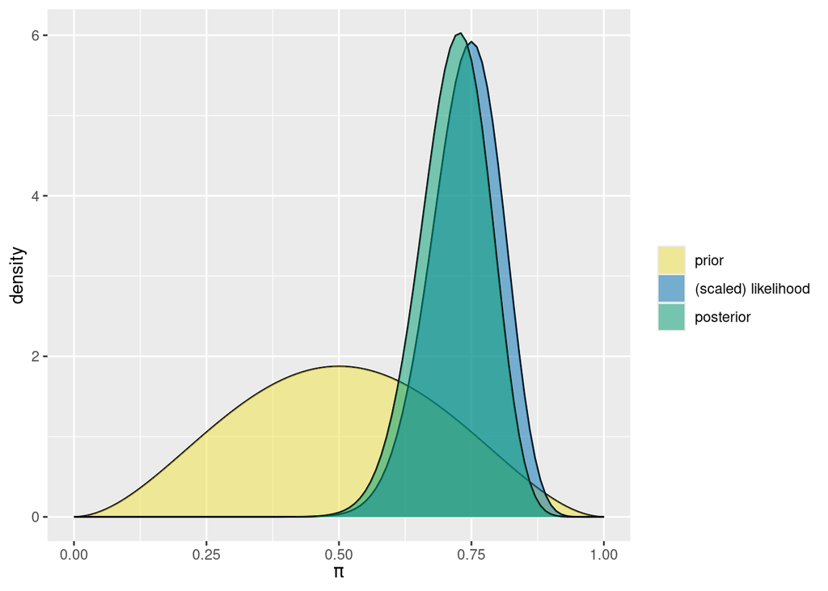

```r
plot_beta_binomial(3,3,30,40)
```

```r
#b
summarize_beta_binomial(3,3,15,20)
```

```
      model alpha beta      mean      mode         var         sd
1     prior     3    3 0.5000000 0.5000000 0.035714286 0.18898224
2 posterior    18    8 0.6923077 0.7083333 0.007889546 0.08882312
```

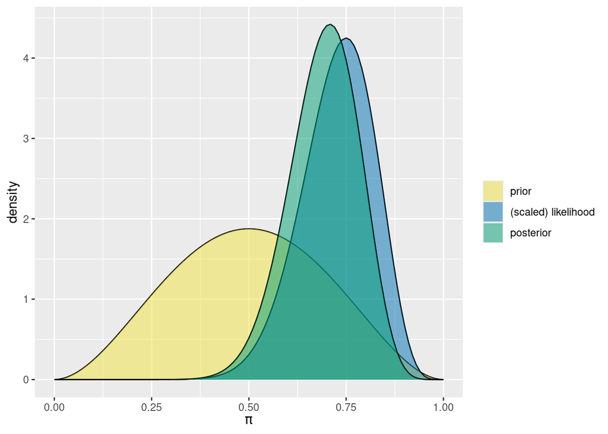

```r
plot_beta_binomial(3,3,15,20)
```

3. Both Patrick and Harold saw the same sample proportion in their data. However, since Patrick’s sample was larger, his posterior has been shifted more towards his sample than Harold’s.

## 4.1

1. centering $pi$ on 0.5
2. somewhat favoring $\pi$ > 0.5
3. strongly favoring $\pi$ < 0.5
4. somewhat favoring $\pi$ < 0.5
5. strongly favoring $\pi$ > 0.5

## 4.7

1. data has more influence
2. prior has more influence
3. prior has more influence
4. equal influence
5. data has more influence

## 4.8

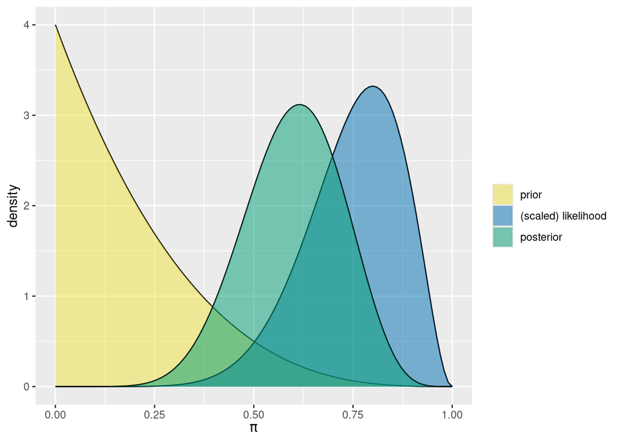

```r
plot_beta_binomial(1,4,8,10)
```

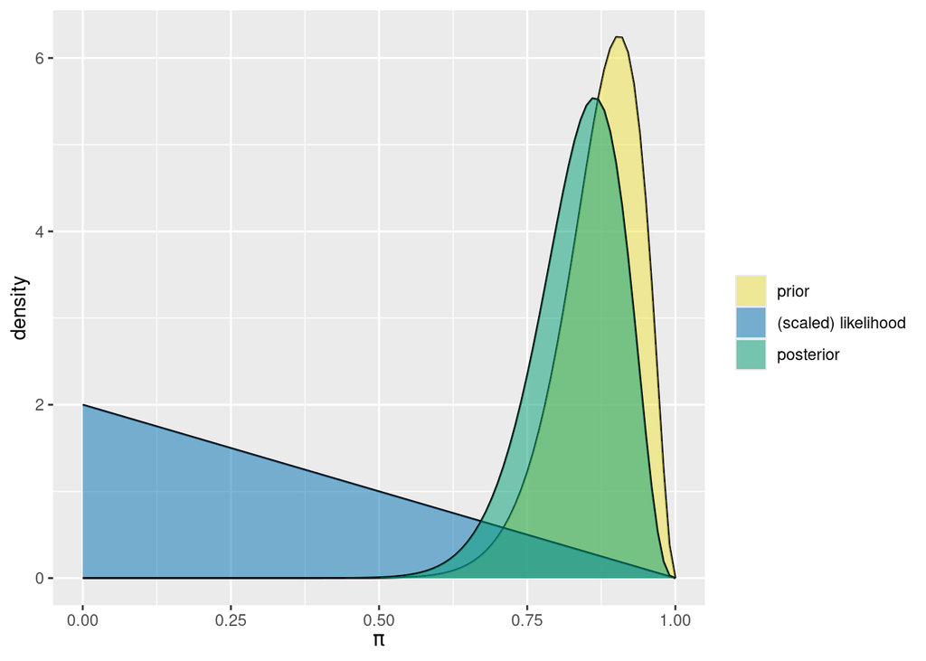

```r
plot_beta_binomial(20,3,0,1)
```

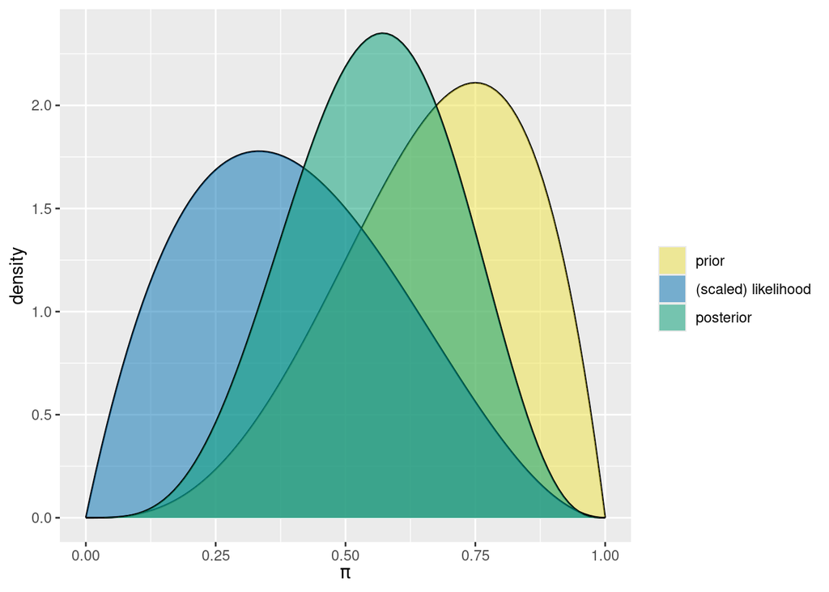

```r
plot_beta_binomial(4,2,1,3)
```

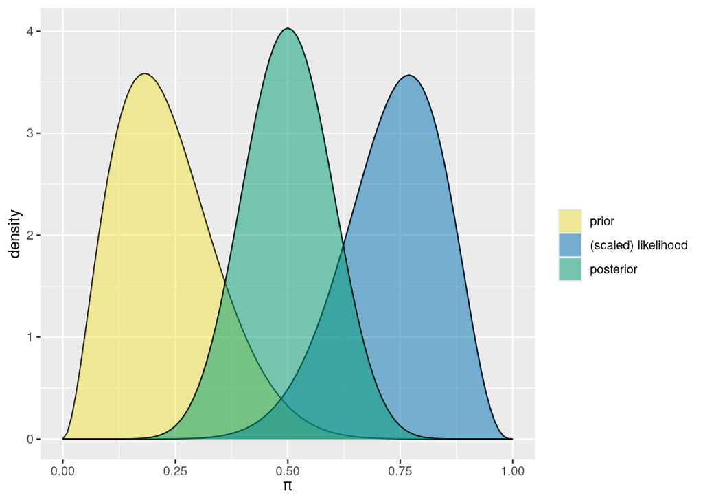

```r
plot_beta_binomial(3,10,10,13)
```

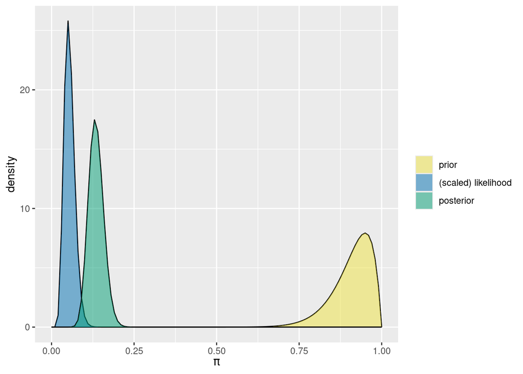

```r
plot_beta_binomial(20,2,10,200)
```

## 4.17

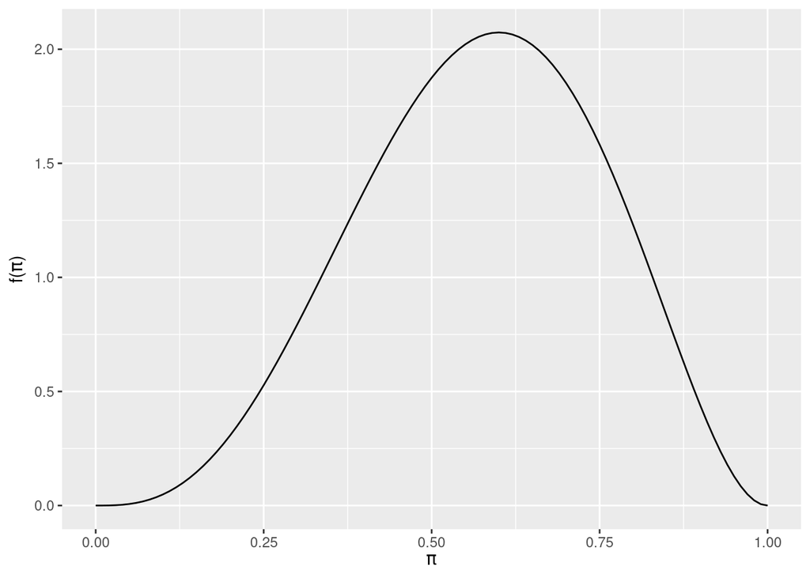

```r
#a
plot_beta(4,3)
```

The most likely probability of a student clicking on the ad is around 60% but we are not very confident in that probability.

2. Beta(4,4) Beta(7,10) Beta(24,83)

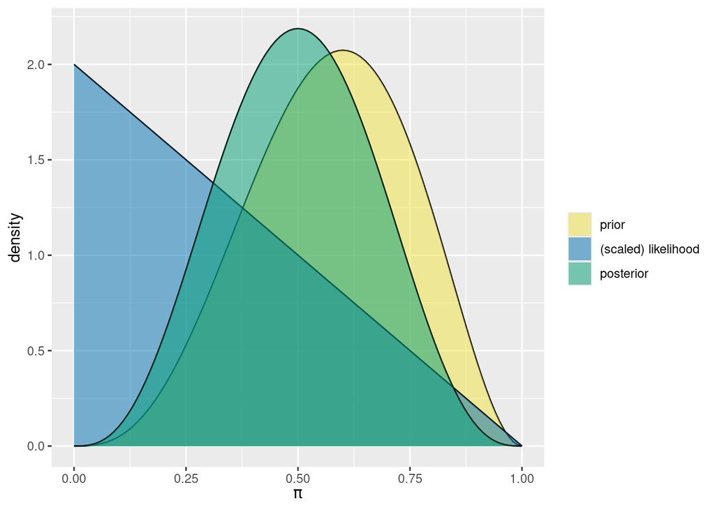

```r
#c
plot_beta_binomial(4,3,0,1)
```

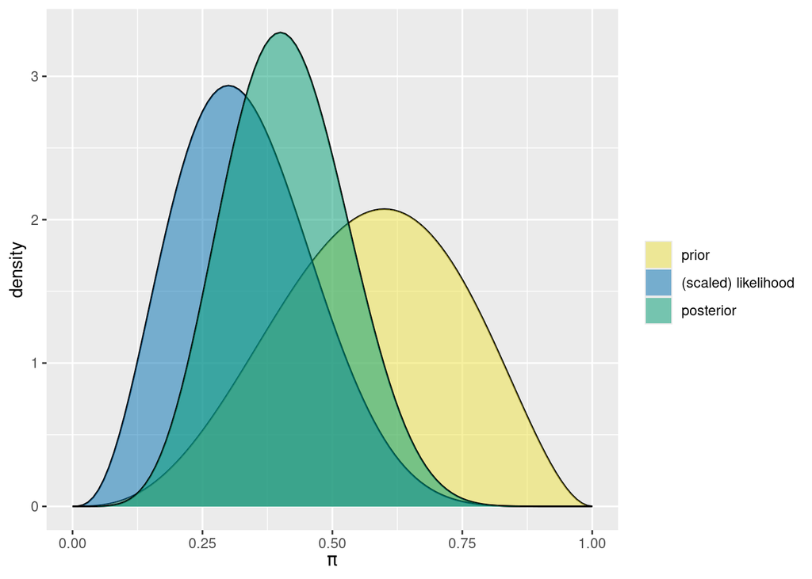

```r
plot_beta_binomial(4,3,3,10)
```

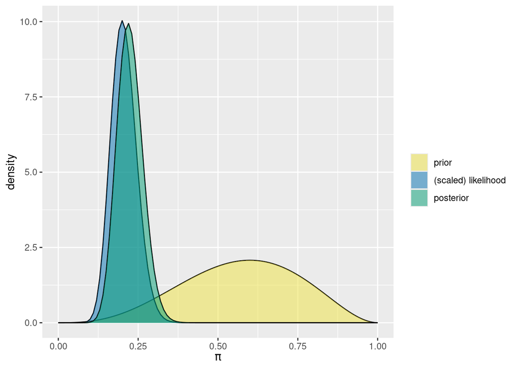

```r
plot_beta_binomial(4,3,20,100)
```

4. The first employee only tested one person so their posterior understanding is similar to the prior, which has a mean of .57. The second employee tested 10 people with a sample proportion of 0.3, so their posterior mean was pulled all the way down to 0.41. The third employee is most heavily influenced by the data and sees the posterior mean pulled all the way to 0.22, just short of the 0.2 sample proportion.

## 4.18

1. Beta(4,4), Beta(7,11), Beta(27,91)

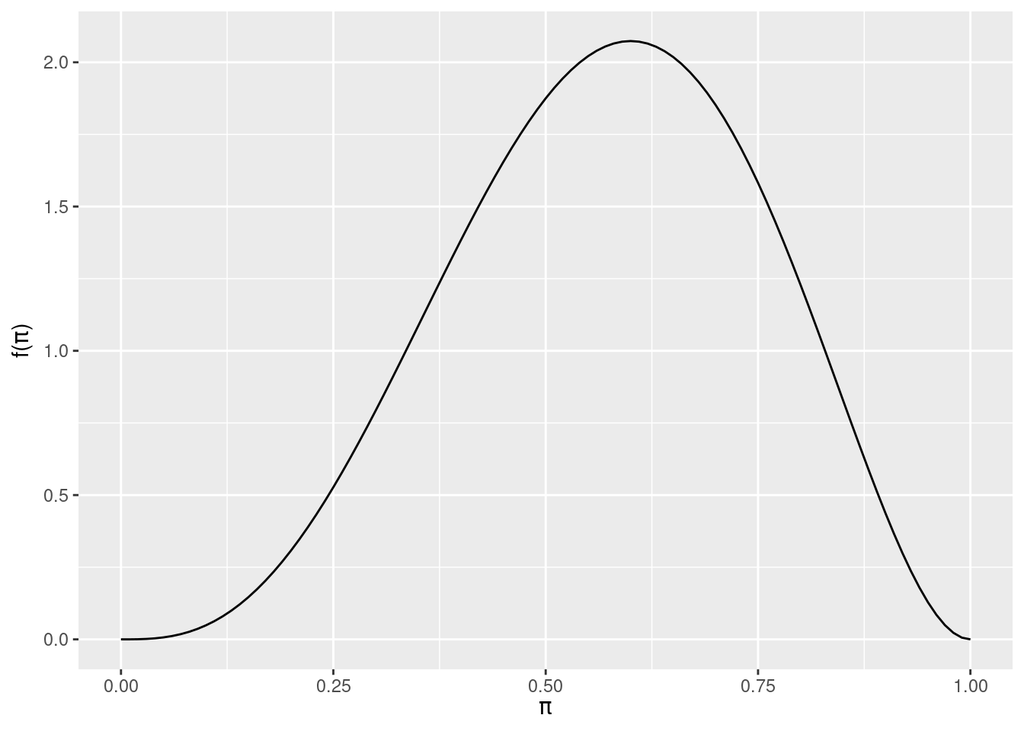

```r
#b
plot_beta(4,3)
```

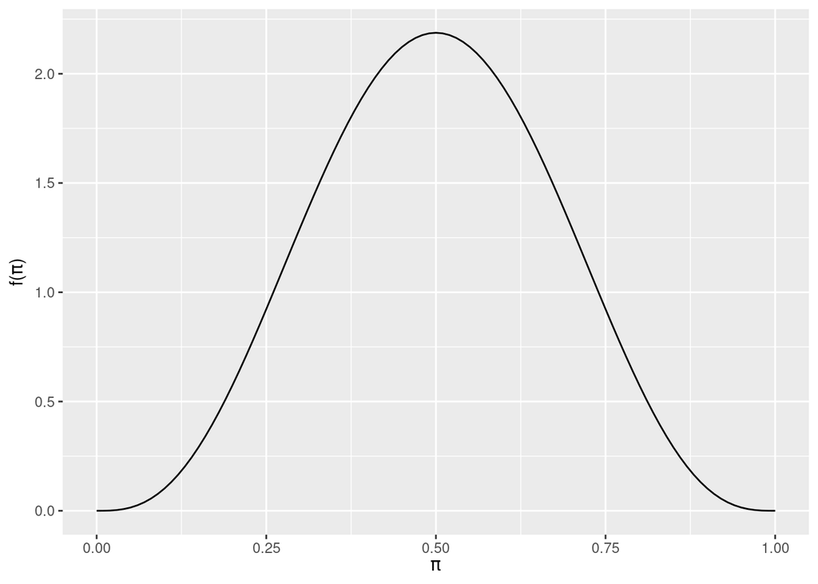

```r
plot_beta(4,4)
```

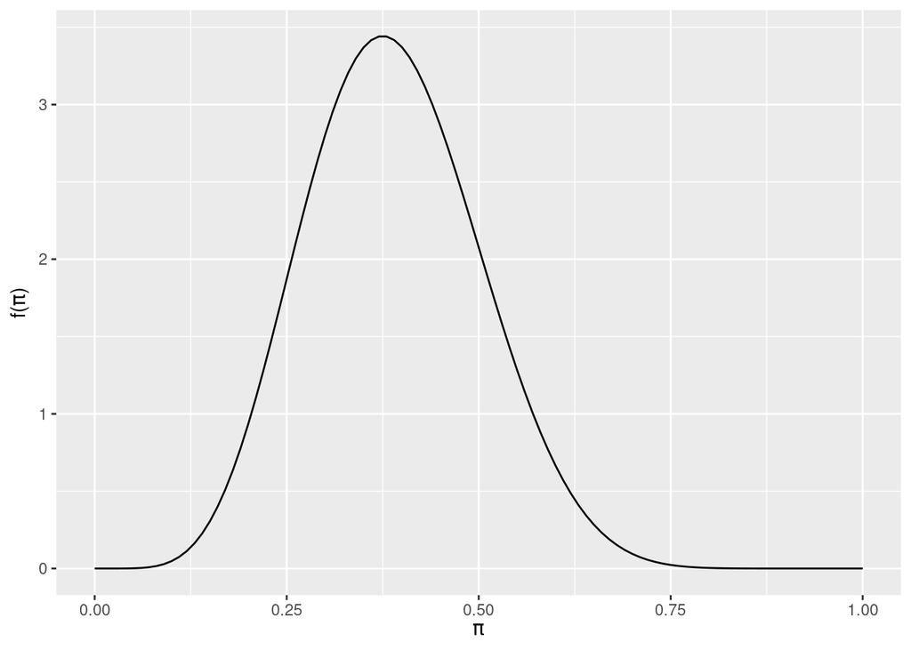

```r
plot_beta(7,11)
```

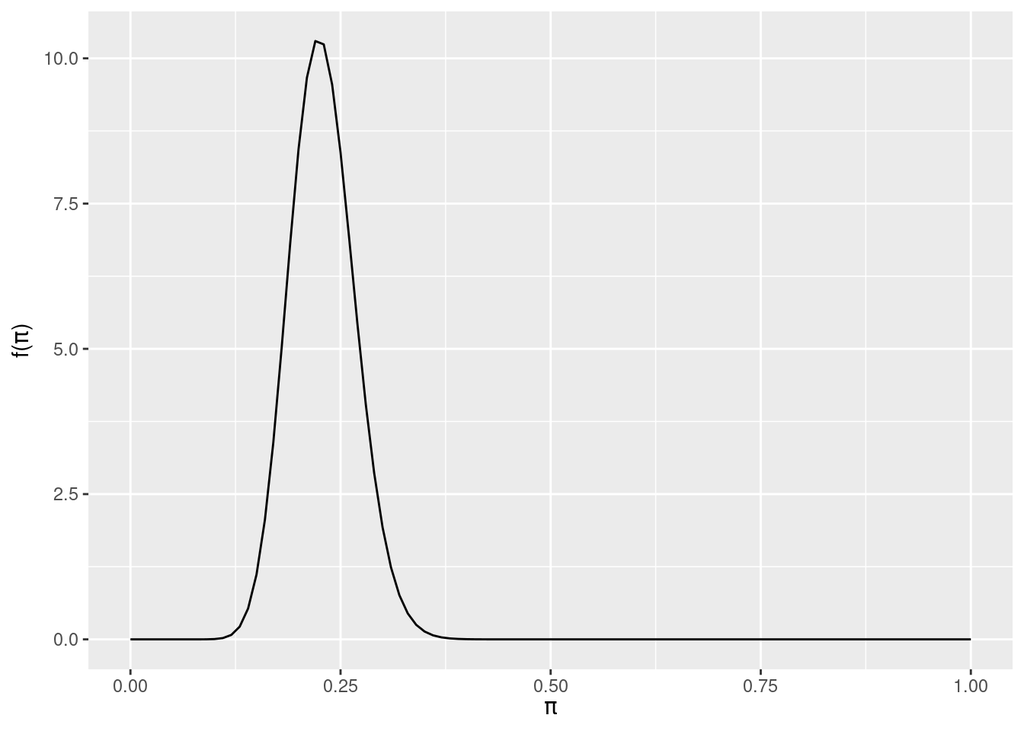

```r
plot_beta(27,91)
```

At first the employee was fairly uncertain about pi, although they thought it was more likely to be larger than 0.5 than smaller than 0.5. After the first day they were still fairly uncertain and also now thought that it was equally likely to be above 0.5 as below 0.5. After the second day they became convinced it was lower than 0.75 and also ruled out any values below about 0.1, with the most plausible values of pi being around 0.4. After the third day they narrowed down their understanding even more, now thinking pi must be between 0.12 and 0.35 with the most likely value slightly below 1/4.

3. It would be a Beta(27,91), the same as the sequentially obtained posterior.

## 5.5

1. Gamma(400,80)

```r
#b
1-pgamma(q=10,shape=400,rate=80)
```

```
[1] 0
```

## 5.6

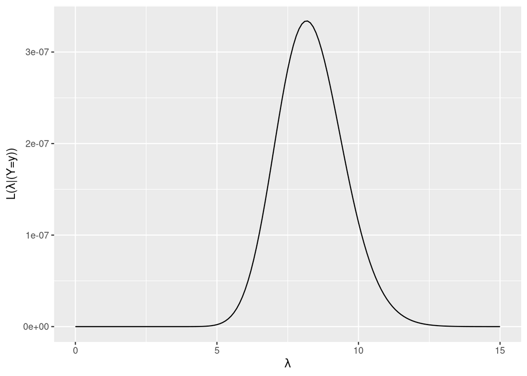

```r
#a
plot_poisson_likelihood(y=c(7,3,8,9,10,12), lambda_upper_bound=15)
```

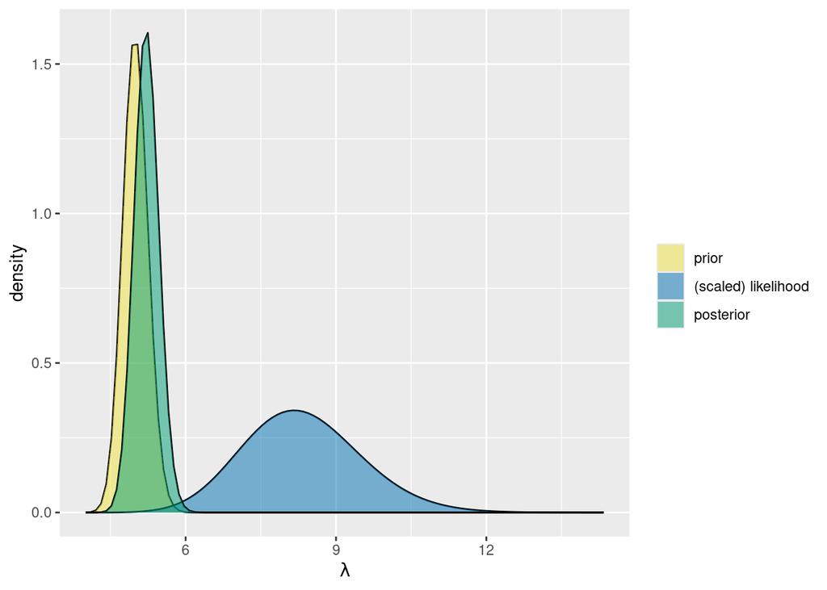

```r
#b
plot_gamma_poisson(400,80,sum_y=49,n=6)
```

```r
#c
summarize_gamma_poisson(400,80,sum_y=49,n=6)
```

```
      model shape rate    mean     mode        var        sd
1     prior   400   80 5.00000 4.987500 0.06250000 0.2500000
2 posterior   449   86 5.22093 5.209302 0.06070849 0.2463909
```

## 5.9

1. Normal(7.2, 2.6^2)

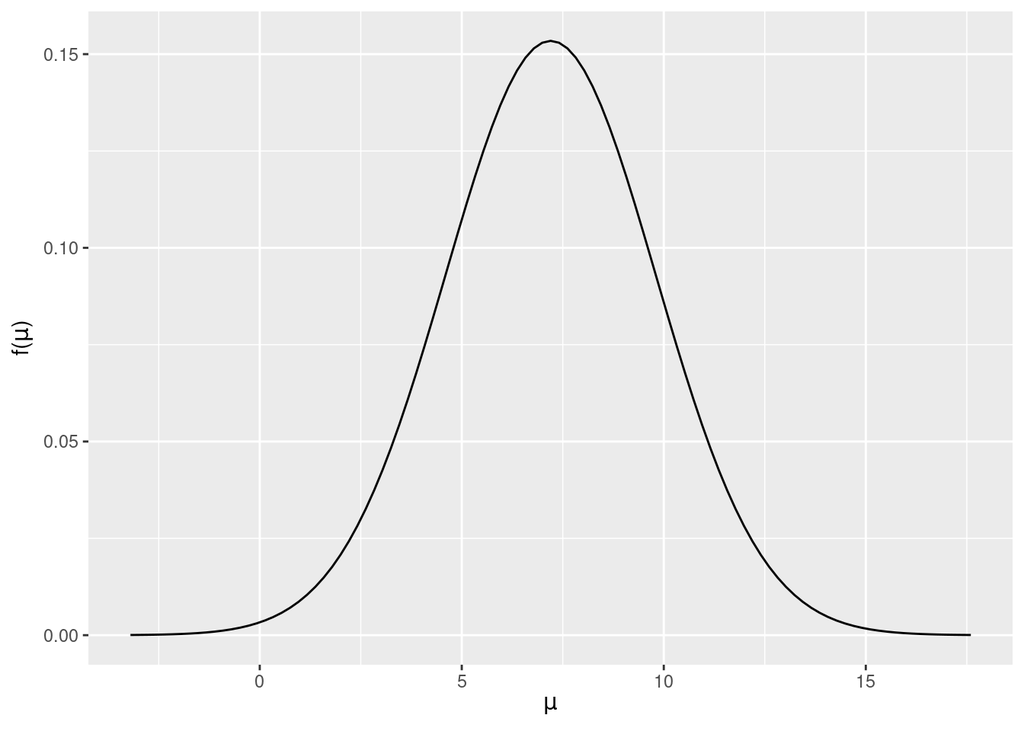

```r
plot_normal(7.2,2.6)
```

2. Yes, 7.6 seems like a fairly plausible value for $\mu$.
3. While less plausible than before, 4 is still a somewhat plausible value of $\mu$.

```r
#d
pnorm(0,mean=7.2,sd=2.6)
```

```
[1] 0.002809441
```

```r
#e
1-pnorm(8,mean=7.2,sd=2.6)
```

```
[1] 0.3791582
```

## 5.10

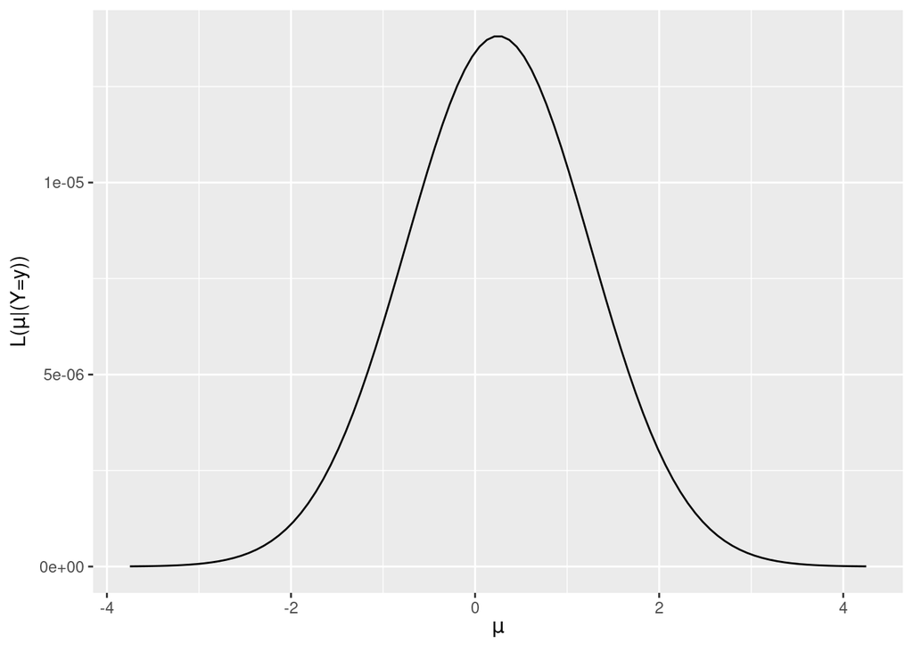

```r
#a
plot_normal_likelihood(y=c(-0.7,1.2,4.5,-4), sigma=2)
```

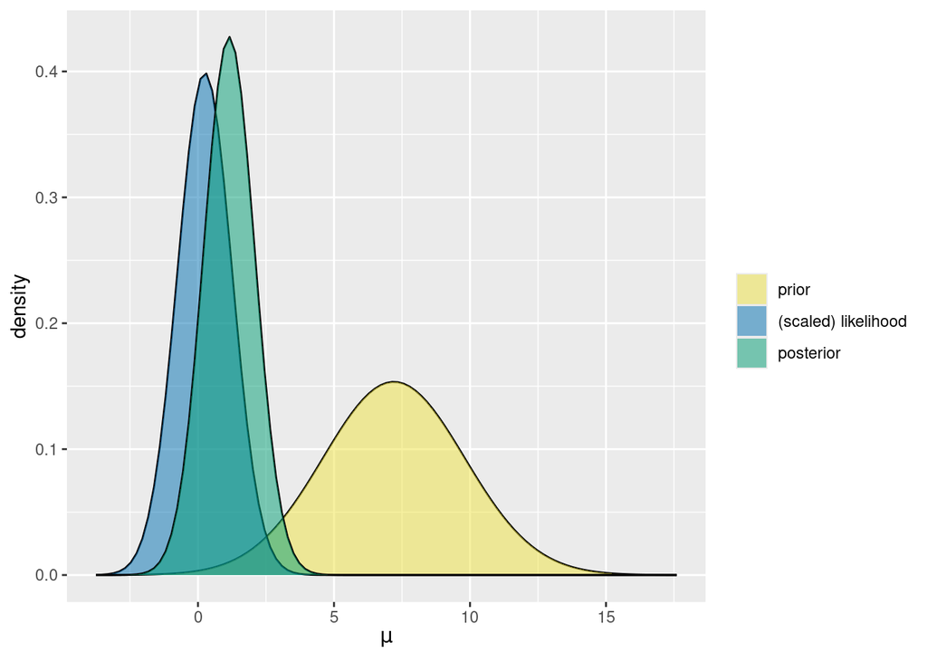

```r
#b
plot_normal_normal(7.2, 2.6, sigma=2, y_bar=mean(c(-0.7,1.2,4.5,-4)), n=4)
```

```r
#c
summarize_normal_normal(7.2, 2.6, sigma=2, y_bar=mean(c(-0.7,1.2,4.5,-4)), n=4)
```

```
      model     mean     mode      var        sd
1     prior 7.200000 7.200000 6.760000 2.6000000
2 posterior 1.145619 1.145619 0.871134 0.9333456
```

4. My prior understanding was that $\mu$ was much larger than the data showed. The prior mean was 7.2 while the mean of the data was 0.25. Because the prior had a relatively large standard deviation compared to the likelihood, the posterior is more similar to the data.

```r
#e
pnorm(0, mean=1.145619, sd=0.9333456)
```

```
[1] 0.10983
```

```r
#f
1-pnorm(8,mean=1.145619, sd=0.9333456)
```

```
[1] 1.036948e-13
```